# Final Project, Stats 506, F20

Hongfan Chen, chenhf@umich.edu

2020/12/12

#### README

This is a write up to Final Project for Stats 506 in Fall 2020.

To build this document, run `Rscript -e "rmarkdown::render('./final_project_Hongfan.Rmd')"` at the command line.

For more information about the code, please visit my **Github** [REPO](https://github.com/HongfanChen/Stats506_final_project)

### 1. Introduction

People usually think commercial buildings open 24 hours would need more work forces to keep the building running. However, is that really so? I decide to answer this question using 2012 CBECS data and let the evidence speak.  
Here’s my question:

> **Do commercial buildings open 24 hours have larger average work forces than those that are not? Does this depend on square footage category and principal activity of the building?**

Since we want to figure out whether differences we might observe are reflective of how the buildings are used (e.g. retail, office space, etc) or of differences in size, we stratify the data by square footage category and principal building activity to facilitate a simple and direct comparison.

### 2. Data / Methods

- **Data**

2012 US Commercial Building Energy Consumption Survey( [CBECS](https://www.eia.gov/consumption/commercial/data/2012/index.php?view=microdata)) data.

- **Variables**

| Variable Name | Description |
| --- | --- |
| `PUBID` | Building identifier |
| `FINALWT` | Final full sample building weight |
| `FINALWT1 - FINALWT197` | Final replicate weight |
| `NWKER` | Number of employees |
| `OPEN24` | Open 24 hours a day |
| `SQFTC` | Square footage category |
| `PBA` | Principal building activity |

#### Analysis

- Using **jackknife** method, variances are estimated by:

$\hat{V} (\hat{\theta}) = \sum_{r=1}^R \alpha_r(\hat{\theta}_r -\hat{\theta})^2$

- 95% Confidence intervals are constructed using:

$\hat{\theta} \pm \Phi^{-1}(.975)\sqrt{\hat{V}(\hat{\theta})}$

**NOTE**:  
*1. Buildings that have only one status of `OPEN24` have been removed from the final analysis, because I want a 1-1 comparison, and these buildings can not be used for computing difference.*

### 3. Results

#### Code Organization

There is only one file needed here to perform analysis: `final.R`

```r
source('./final.R')
```

#### TABLE: Average Work Forces and Difference

```r
cap = paste0(
"**Table 1.** *Average work forces and difference of two status.*",
" Values round off to 3 decimal digit, with 95% confidence intervals, ",
"grouped by square footage category.")
DT::datatable(tab)
```

|  | Square Footage Category | Principal Building Activity | Difference | OPEN 24 | Not OPEN 24 |
| --- | --- | --- | --- | --- | --- |
| 1 | 1,001 to 5,000 square feet | Vacant | -0.093 (-0.174--0.012) | 0.000 (0.000-0.000) | 0.093 (0.012-0.174) |
| 2 | 1,001 to 5,000 square feet | Office | -1.727 (-3.854-0.400) | 3.888 (1.820-5.956) | 5.615 (5.118-6.112) |
| 3 | 1,001 to 5,000 square feet | Nonrefrigerated warehouse | -0.550 (-1.748-0.647) | 1.311 (0.199-2.424) | 1.861 (1.418-2.304) |
| 4 | 1,001 to 5,000 square feet | Food sales | 1.329 (0.015-2.643) | 4.152 (2.978-5.325) | 2.823 (2.232-3.414) |
| 5 | 1,001 to 5,000 square feet | Public order and safety | 1.611 (-4.140-7.362) | 7.078 (3.601-10.555) | 5.467 (0.886-10.048) |
| 6 | 1,001 to 5,000 square feet | Religious worship | 0.590 (-6.508-7.689) | 3.355 (-3.720-10.430) | 2.765 (2.186-3.343) |
| 7 | 1,001 to 5,000 square feet | Public assembly | 0.351 (-3.119-3.822) | 3.198 (-0.145-6.541) | 2.847 (1.916-3.777) |
| 8 | 1,001 to 5,000 square feet | Education | 0.795 (-9.028-10.617) | 5.000 (-4.800-14.800) | 4.205 (3.535-4.876) |
| 9 | 1,001 to 5,000 square feet | Food service | 1.950 (-2.695-6.594) | 8.355 (3.764-12.945) | 6.405 (5.697-7.113) |
| 10 | 1,001 to 5,000 square feet | Lodging | 2.760 (1.470-4.050) | 2.760 (1.470-4.050) | 0.000 (0.000-0.000) |

[output cut: 86 more lines]

**Table 1.** *Average work forces and difference of two status.* Values round off to 3 decimal digit, with 95% confidence intervals, grouped by square footage category.

### Difference of Average work forces.

#### First Group

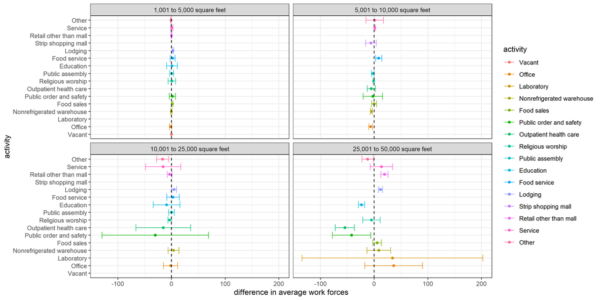

```r
knitr::include_graphics("./graph/1.png")
```

#### Second Group

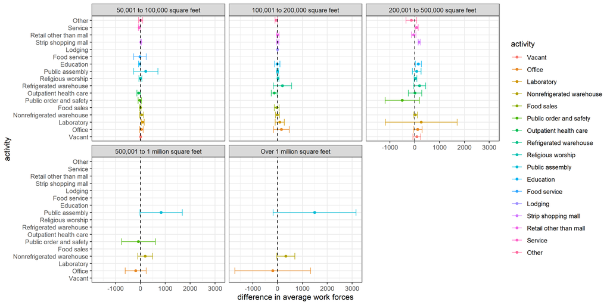

```r
knitr::include_graphics("./graph/2.png")
```

### 4. Conclusion / Discussion

The answer for the question is:

> **It depends.**

#### **Limitation**

In real life, the average work forces would be affected by more **factors**. Things are much more complicated than what data shows, the variances are large among many buildings, so the outcome may be incorrect unless we have more observations.